# SVAlignR and Virus-Associated Cancer

# Aligning Clustered Sequences

Each of the clusters uses a small enough set of symbols that we can safely rewrite them as though they are sequences of amino acids. We then use the `align` function from the `SVAlignR` package to perform multiple sequence alignments, using the “ClustalW” algorithm on each cluster. Because the components are not amino acids, however, we do not need to use one of the PAM or BLOSUM matrices. Instead, we define a substitution matrix that gives the same match and mismatch scores to each pair of symbols.

```r
if (!requireNamespace("msa", quietly = TRUE)) {
  stop("Cluster alignment only works if the `msa` package is available.")
}
MYSUB <- makeSubsMatrix(match = 2, mismatch = -6)
consensus <- alignAllClusters(seqclust, mysub = MYSUB, gapO = 2, gapE = 0.1)
```

[output not shown]

```r
class(consensus)
```

```
## [1] "list"
```

```r
length(consensus)
```

```
## [1] 15
```

**Figure 5** contains an example of a multiple sequence alignment.

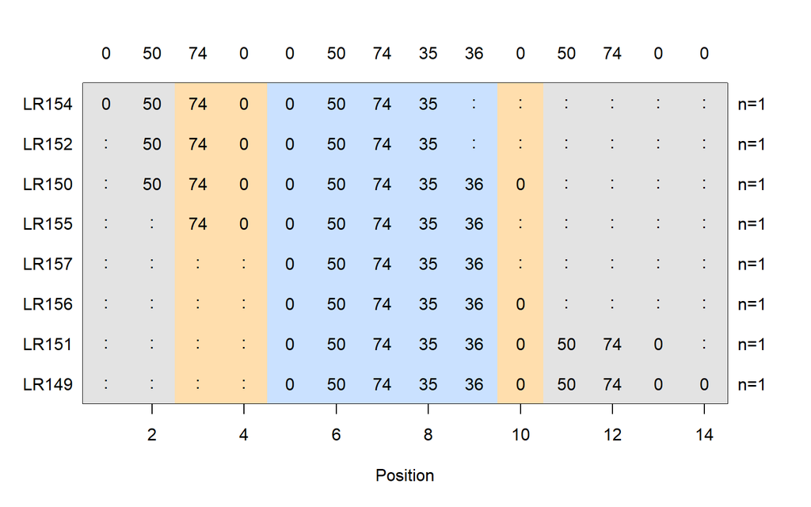

Figure 5: Example alignment of cluster 15.

```r
opar <- par(mai = c(1.02, 0.82, 0.82, 0.82))
image(consensus[[15]])
```

```r
par(opar)
rm(opar)
```

## Alignments By Cluster

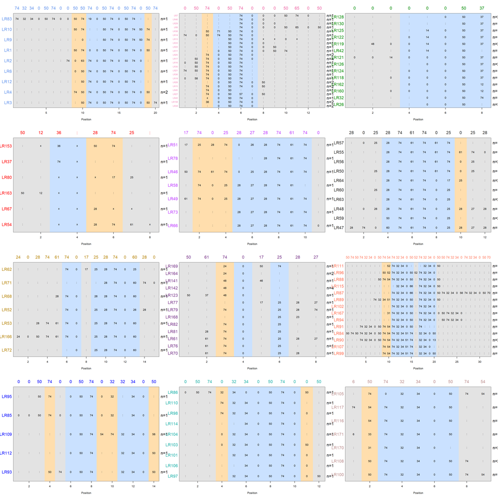

Figure 6: Multiple sequence alignments of clusters.

```r
opar <- par(mfrow = c(4,3))
for (K in 1:length(consensus)) {
  image(consensus[[K]], col = SVAlignR:::myColorSet[K])
}
```

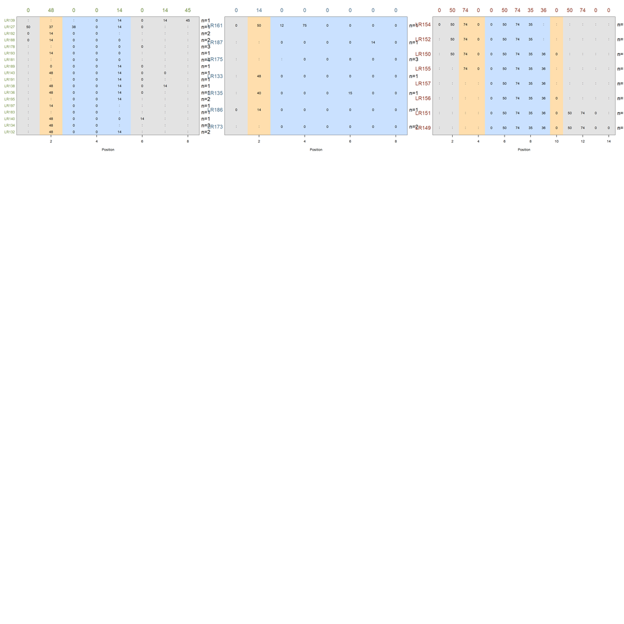

Figure 6: Multiple sequence alignments of clusters.

```r
par(opar)
```

## Consensus Sequences

```r
library(dendextend)
```

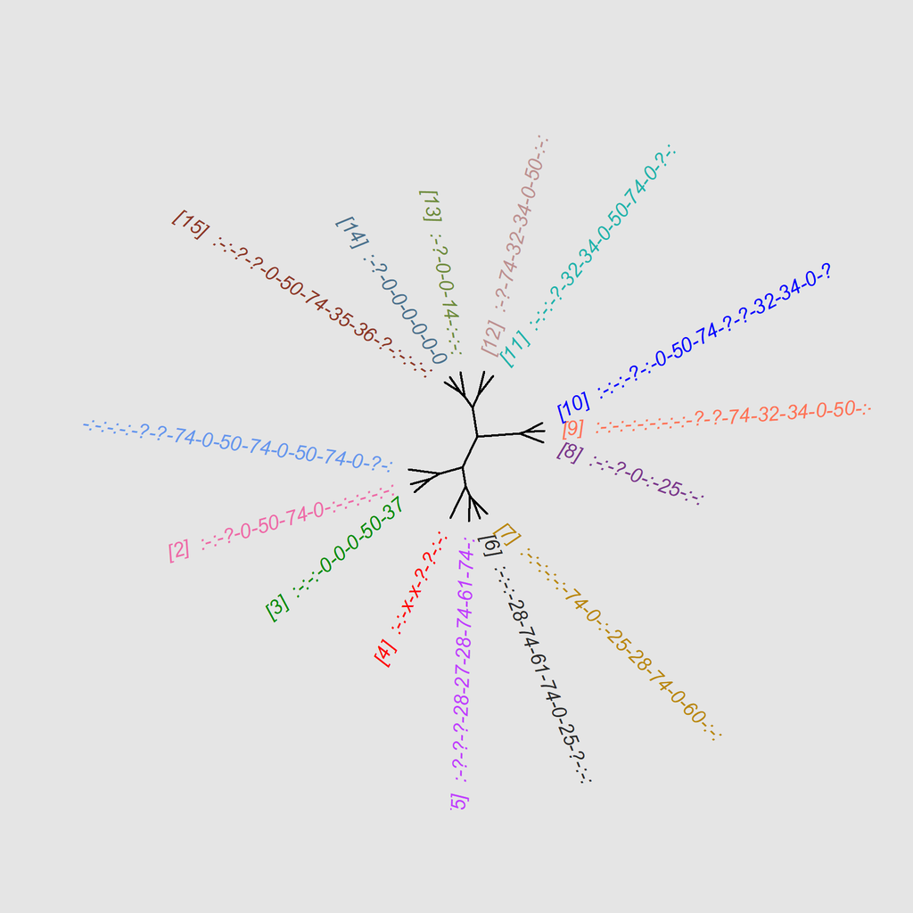

Figure 7: Unrooted phylogeny tree with consensus sequences.

```r
myColorSet <- SVAlignR:::myColorSet
NC <- seqclust@NC
mycut <- mean(rev(seqclust@hc$height)[NC + -1:0])
hcd <- as.dendrogram(seqclust@hc)
dend2 <- cut(hcd, h = mycut)
DU <- dend2$upper
blocks <- sapply(consensus, function(X) {
  X@consensus
})
labels(DU) <- paste("   [", 1:NC, "]  ",  blocks, "   ", sep = "")

opar <- par(bg = "gray90")
plot(ape::as.phylo(DU), type = "unrooted", rotate.tree = -20,
     edge.color = "black", edge.width = 2,
     lab4ut = "axial",
     tip.color = myColorSet[1:NC], cex = 1.2)
```

```r
par(opar)
```

# De Bruijn Graphs

We also provide the ability to compute de Bruijn graphs from any set of sequences. These graphs are frequently used for “de novo” sequencing, and thus can provide an alternative source of information about “consensus sequence” alignments. In order to work with graphs in general, you should load the `igraph` package.

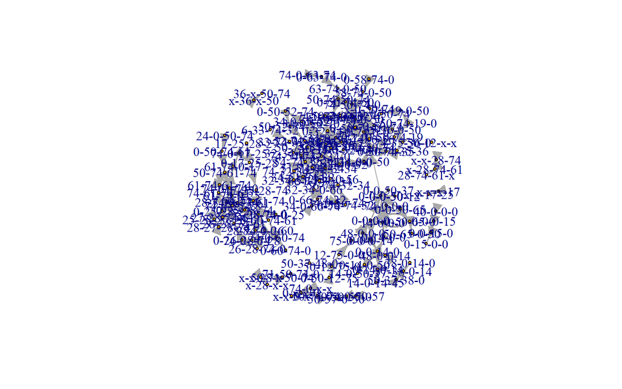

```r
library("igraph")
DB <- deBruijn(seqclust@rawSequences, 4)
G <- DB@G
loci <- layout_with_fr(G)
plot(G, layout = loci)
```

```r
count_components(G)
```

```
## [1] 13
```

```r
comp <- components(G)
sort(comp$csize)
```

```
##  [1]  1  1  2  2  2  2  3  3  3  4  4 32 84
```

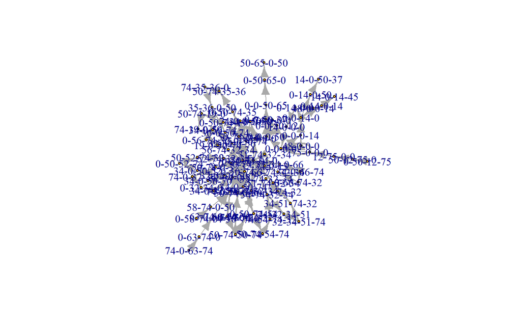

```r
GC <- largest_component(G)
gloc <- layout_with_gem(GC)
plot(GC, layout = gloc)
```

```r
sort(table(E(GC)$weight))
```

```
##
##  6 11 17 20 21 28  7  8 14  9  4  3  5  2  1
##  1  1  1  1  1  1  2  2  2  3  6  8  8 21 46
```

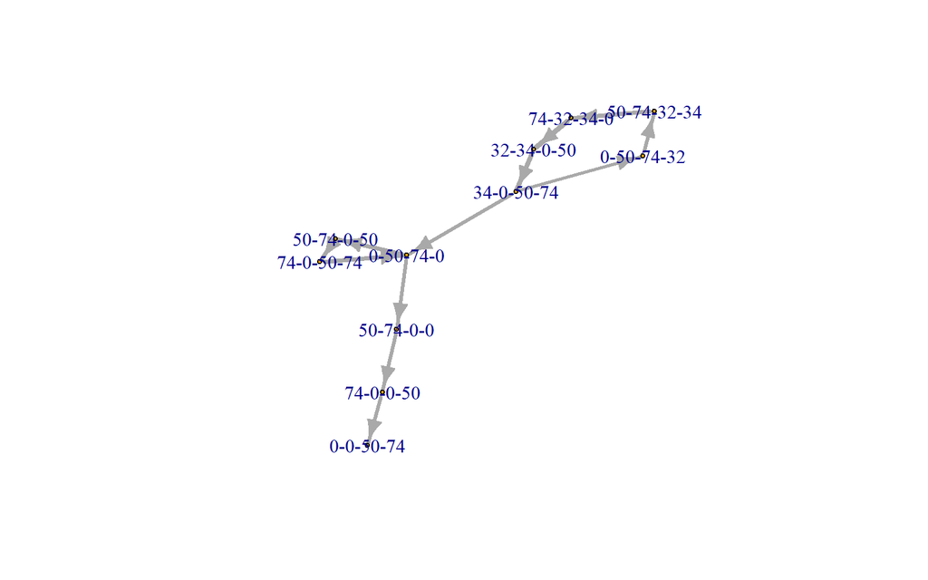

```r
GE <- delete_edges(GC, E(GC)[E(GC)$weight  < 6])
GE <- largest_component(GE)
#GE <- set_edge_attr(GE, "width", value = sqrt(edge_attr(G, "weight")))
gloc <- layout_with_fr(GE)
plot(GE, layout = gloc)
```

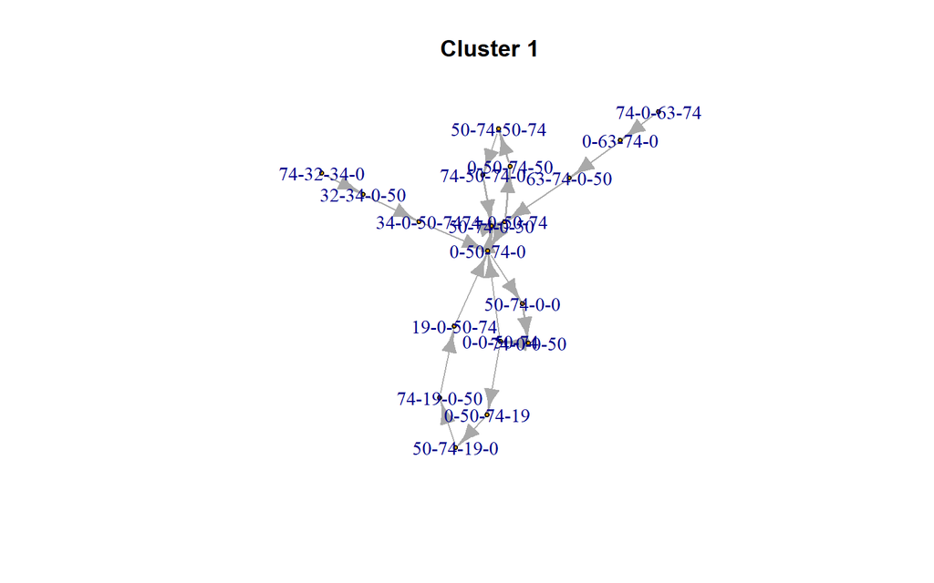

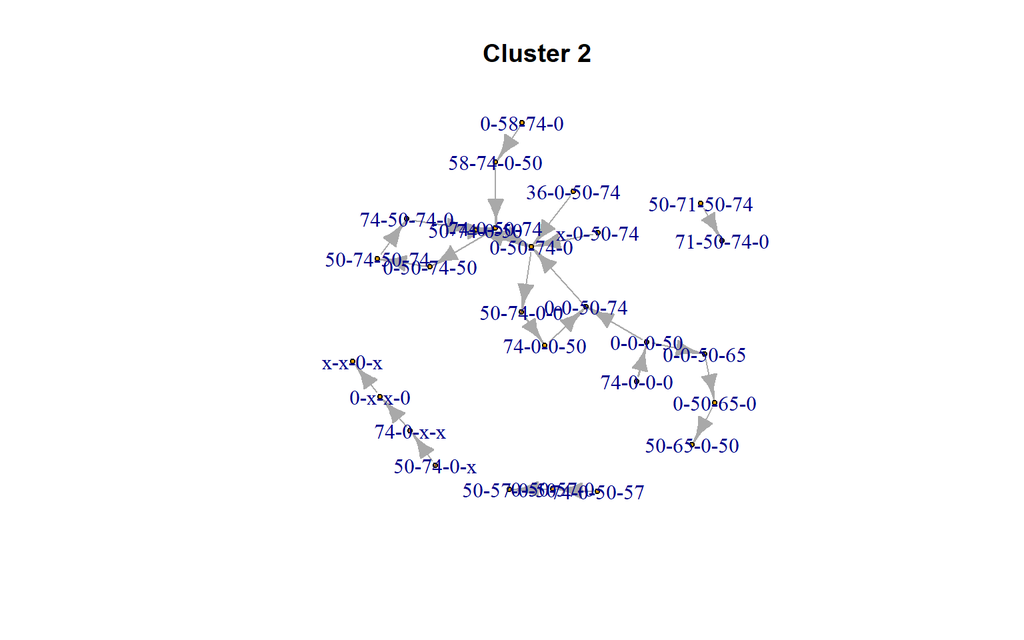

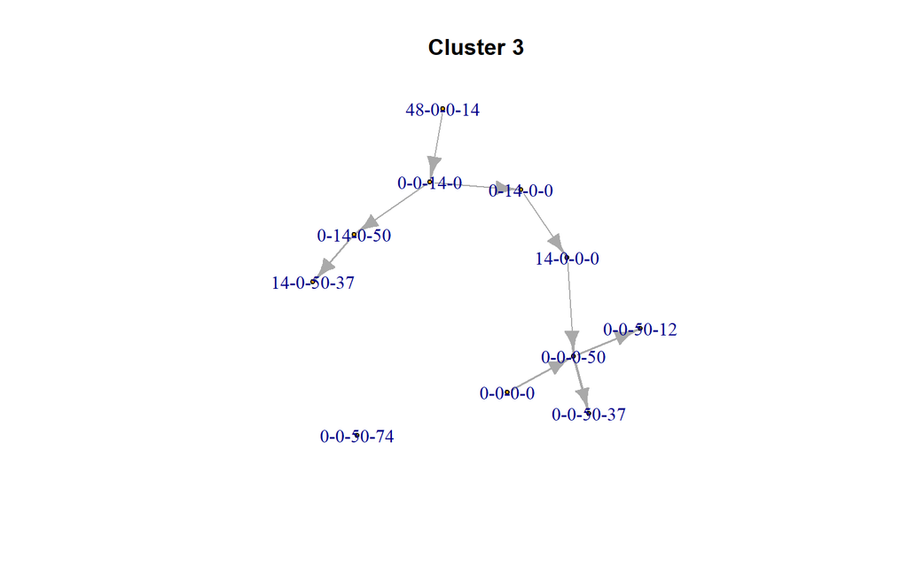

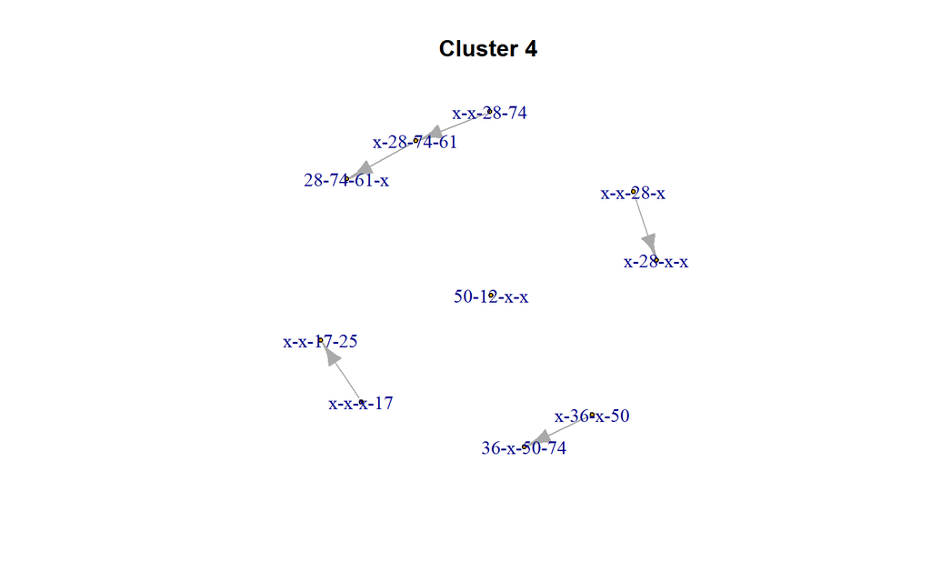

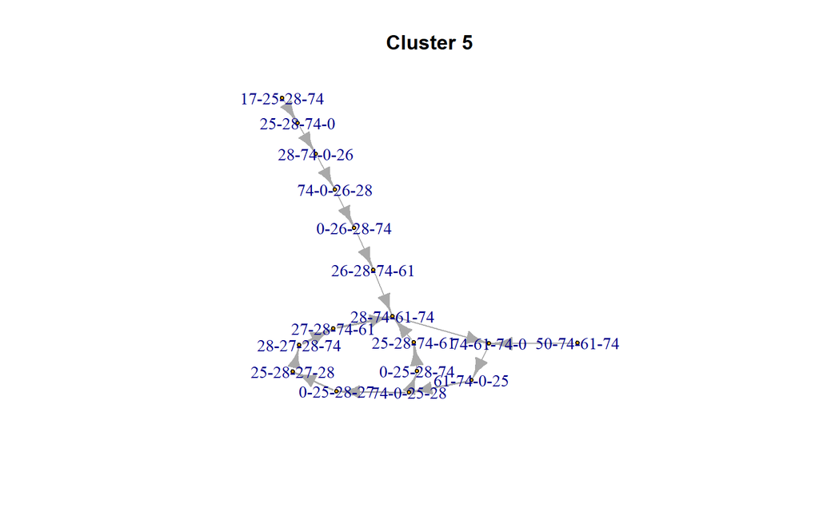

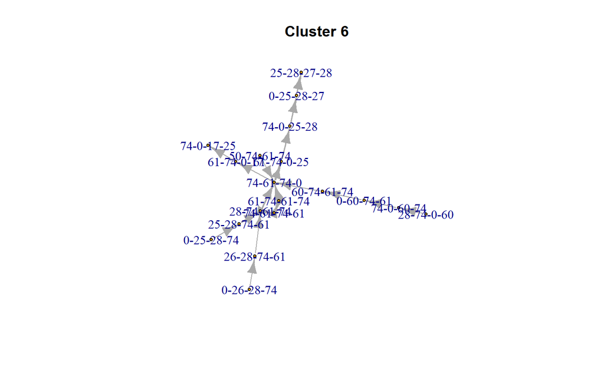

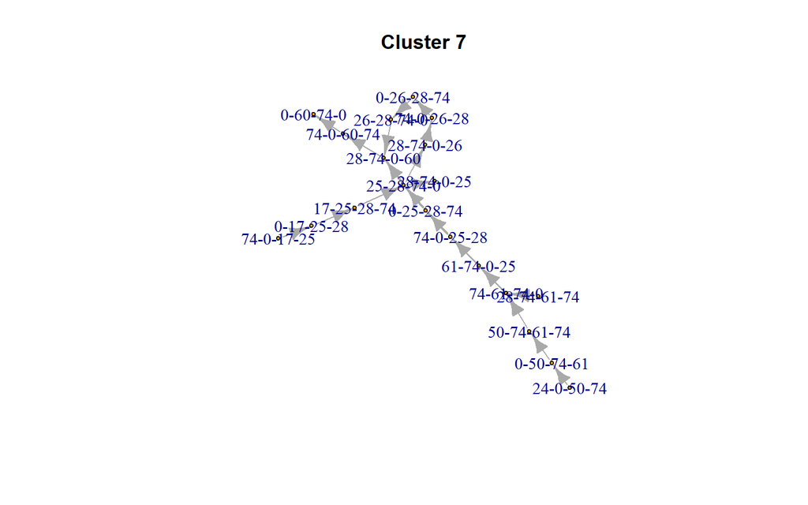

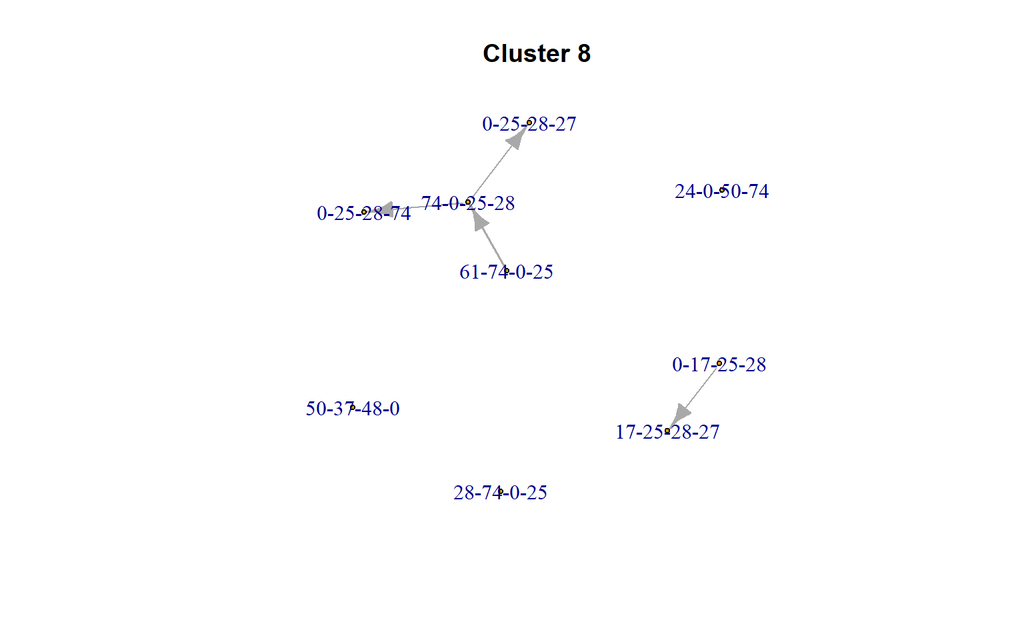

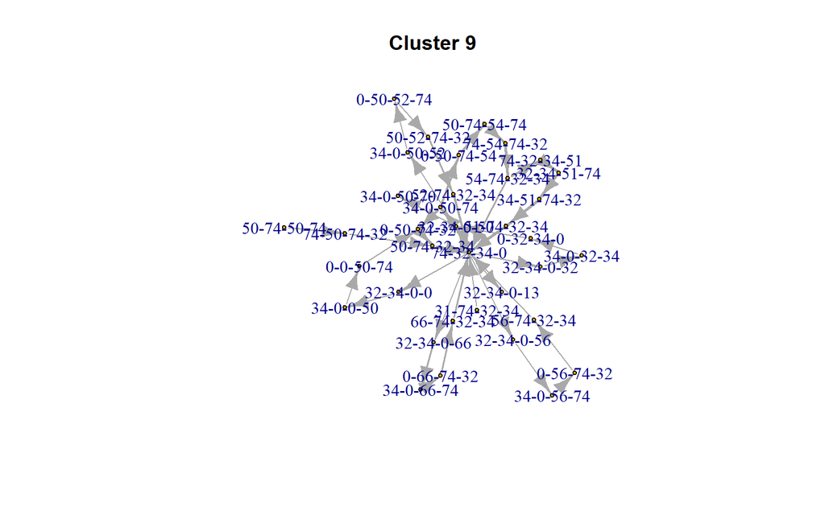

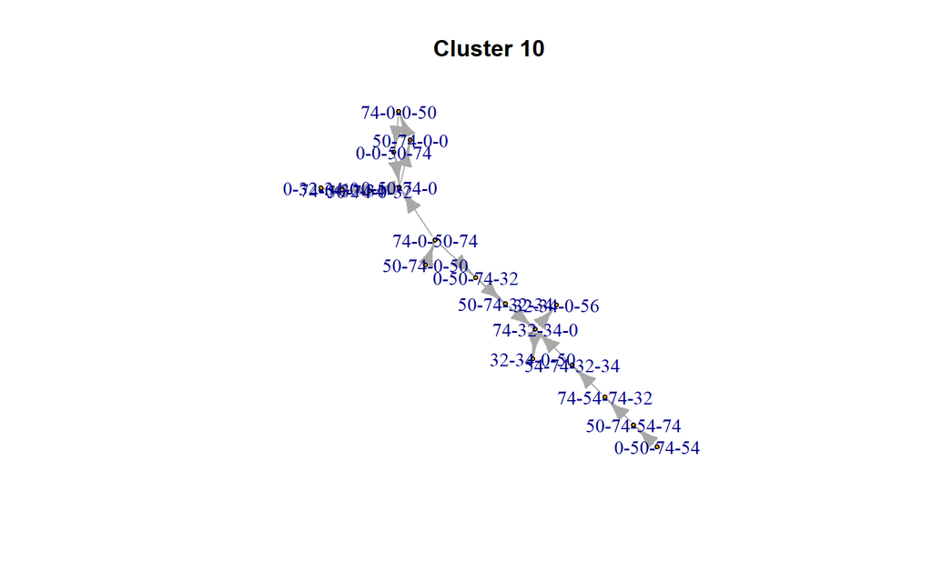

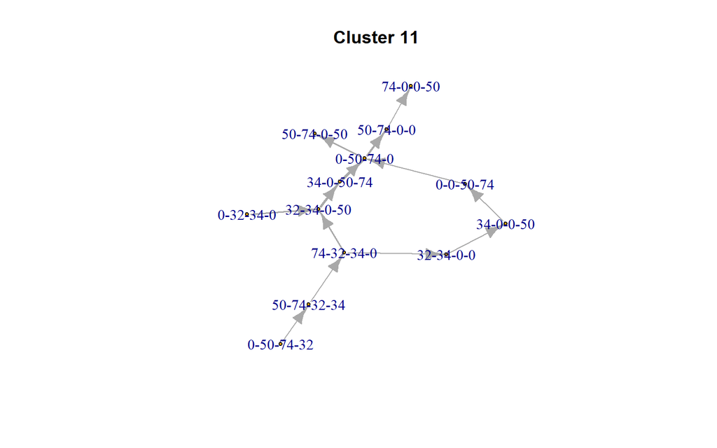

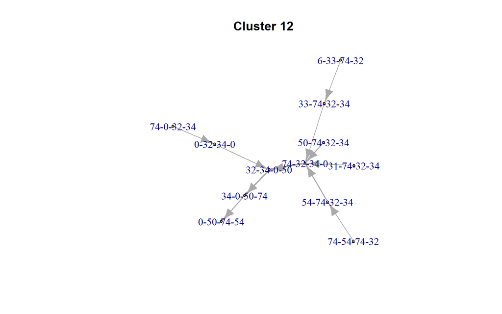

[3 more figures not shown]

```r
dbset <- lapply(1:seqclust@NC, function(J) {
  rs <- seqclust@rawSequences[seqclust@clusters == J]
  db <- deBruijn(rs, 4)
})
L <- length(dbset)
for (I in 1:L) {
  G <- dbset[[I]]@G
  lyt <- layout_with_fr(G)
  plot(G, layout =lyt, main = paste("Cluster", I))
}
```